# Анализ зависимостей на примерах

```python
import numpy as np
import pandas as pd
import scipy.stats as sps
from sklearn.ensemble import RandomForestRegressor

from scipy.cluster.hierarchy import dendrogram, linkage, fcluster
from scipy.spatial.distance import squareform
from statsmodels.sandbox.stats.multicomp import multipletests

import matplotlib.pyplot as plt
from matplotlib import colors
import seaborn as sns
sns.set(style='white', font_scale=1.2, rc=sns.axes_style())

# sns.set(font_scale=1.3, palette='Set2')

# from ipywidgets import interact, widgets
# from IPython.display import display
```

## 1. Вещественные признаки

### 1.1. Анализ температуры городов России

Изучим зависимости между широтой, долготой и средней минимальной температуры января по крупым городам России

```python
cities = pd.read_csv('./cities.csv', sep='\t')
cities.head()
```

|  | Город | Широта | Долгота | Страна | Ср. мин. температура января |
| --- | --- | --- | --- | --- | --- |
| 0 | Абакан | 53.720976 | 91.442423 | Россия | -22.0 |
| 1 | Анадырь | 64.733330 | 177.516670 | Россия | -26.2 |
| 2 | Архангельск | 64.539304 | 40.518735 | Россия | -16.5 |
| 3 | Астрахань | 46.347869 | 48.033574 | Россия | -6.5 |
| 4 | Барнаул | 53.356132 | 83.749620 | Россия | -20.1 |

Визуализируем данные на карте

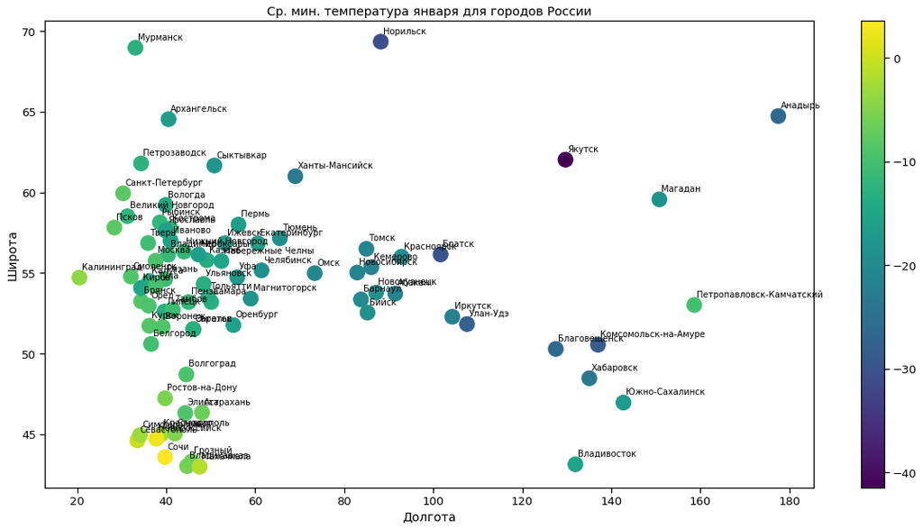

```python
plt.figure(figsize=(20, 10))
plt.scatter(
    cities['Долгота'], cities['Широта'],
    c=cities['Ср. мин. температура января'], s=300
)
for i in range(len(cities)):
    plt.annotate(
        cities['Город'][i],
        (cities['Долгота'][i] + 0.5,
         cities['Широта'][i] + 0.5),
        fontsize=10
    )

plt.colorbar()
plt.xlabel('Долгота')
plt.ylabel('Широта')
plt.title('Ср. мин. температура января для городов России')
plt.show()
```

Функция, вычисляющая все **попарные корреляции Спирмена** и соответствующие p-value и визуализирующая их в виде таблицы.

```python
labels = ['Долгота', 'Широта', 'Температура']

def visualize_spearman_correlation(x, y, t):
    '''
    Визуализация корреляции Спирмена и p-value
    '''

    correlation, pvalue = sps.spearmanr(np.stack((x, y, t)), axis=1)

    plt.figure(figsize=(12, 5))
    plt.suptitle('Зависимости между всеми парами признаков', y=1.01)

    plt.subplot(1, 2, 1)
    sns.heatmap(
        correlation, annot=True,
        xticklabels=labels, yticklabels=labels,
        cmap='seismic', vmin=-1, vmax=1
    )
    plt.title('Коэфф. корреляции Спирмена')

    plt.subplot(1, 2, 2)
    sns.heatmap(
        pvalue, annot=True,
        xticklabels=labels, yticklabels=labels,
        vmin=0, vmax=0.05,
        cmap='Reds_r'
    )
    plt.title('p-value гипотез')

    plt.show()
```

Корреляции Спирмена по всем парам переменных. Видим значимую корреляцию каждой координаты с температурой. Гипотеза о независимости широты и долготы не отклоняется.

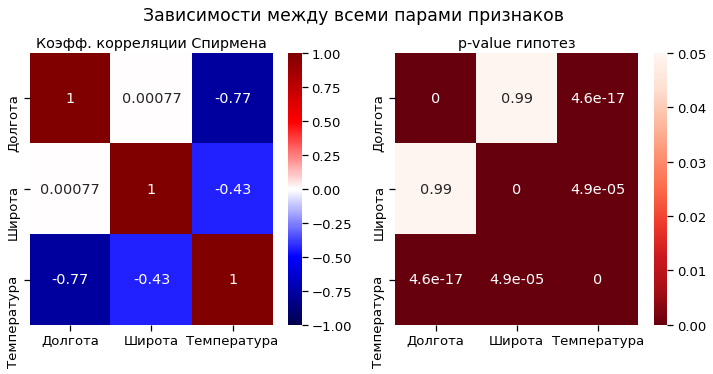

```python
visualize_spearman_correlation(
    cities['Долгота'],
    cities['Широта'],
    cities['Ср. мин. температура января']
)
```

#### Только европейская часть.

Оставим только города западнее Екатеринбурга, поскольку тут больше городов

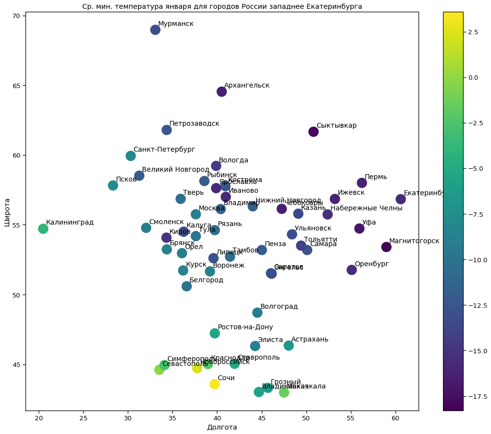

```python
euro_cities = cities[
    cities['Долгота'] <= float(cities['Долгота'][cities['Город'] == 'Екатеринбург'])
]

plt.figure(figsize=(18, 15))
plt.scatter(
    euro_cities['Долгота'],
    euro_cities['Широта'],
    c=euro_cities['Ср. мин. температура января'],
    s=400
)
for i in range(len(euro_cities)):
    plt.annotate(
        euro_cities['Город'].iloc[i],
        (euro_cities['Долгота'].iloc[i] + 0.3,
         euro_cities['Широта'].iloc[i] + 0.3),
        fontsize=14)

plt.colorbar()

plt.xlabel('Долгота')
plt.ylabel('Широта')
plt.title('Ср. мин. температура января для городов России западнее Екатеринбурга')
plt.show()
```

Посмотрим на коэффициенты корреляции Спирмена и их p-value

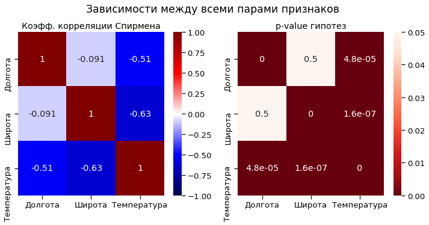

```python
visualize_spearman_correlation(
    euro_cities['Долгота'],
    euro_cities['Широта'],
    euro_cities['Ср. мин. температура января']
)
```

### 1.2. Зависимость рейтинга отелей от разных факторов

Загрузим [информацию](https://github.com/Yorko/mlcourse_open/blob/master/data/hostel_factors.csv) о нескольких отелях — рейтинг, цена, качество, услуги.

```python
hostel = pd.read_csv(
    'hostel_factors.csv',
    skiprows=1,
    names=[
        'Отель', 'Персонал', 'Бронирование хостела',
        'Заезд в хостел и выезд из хостела', 'Состояние комнаты',
        'Состояние общей кухни', 'Состояние общего пространства',
        'Дополнительные услуги', 'Общие условия и удобства',
        'Цена/качество', 'ССЦ', 'Рейтинг'
    ]
)

hostel.head()
```

|  | Отель | Персонал | Бронирование хостела | Заезд в хостел и выезд из хостела | Состояние комнаты | Состояние общей кухни | Состояние общего пространства | Дополнительные услуги | Общие условия и удобства | Цена/качество | ССЦ | Рейтинг |
| --- | --- | --- | --- | --- | --- | --- | --- | --- | --- | --- | --- | --- |
| 0 | hostel1 | 0.675000 | 0.100000 | 0.300000 | 0.875000 | 0.250000 | 0.425000 | 0.350000 | 0.725000 | 0.400000 | 0.275000 | 9.0 |
| 1 | hostel2 | 0.500000 | 0.000000 | 0.058824 | 0.573529 | 0.117647 | 0.382353 | 0.000000 | 0.161765 | 0.308824 | 0.000000 | 8.3 |
| 2 | hostel3 | 0.520833 | 0.041667 | 0.020833 | 0.666667 | 0.229167 | 0.437500 | 0.270833 | 0.250000 | 0.395833 | 0.270833 | 8.6 |
| 3 | hostel4 | 0.692308 | 0.038462 | 0.038462 | 0.346154 | 0.076923 | 0.307692 | 0.500000 | 0.115385 | 0.153846 | 0.269231 | 7.6 |
| 4 | hostel5 | 0.620690 | 0.000000 | 0.000000 | 0.517241 | 0.172414 | 0.344828 | 0.172414 | 0.379310 | 0.103448 | 0.310345 | 8.7 |

Количество отелей

```python
len(hostel)
```

```
18
```

**Корреляции Спирмена** признаков со значением рейтинга. Полученные числа имеют смысл степени влияния признака на рейтинг отеля.

```python
correlations = hostel.corr(method='spearman')['Рейтинг'].iloc[:-1].sort_values()
correlations
```

```
Цена/качество                       -0.351298
Состояние комнаты                   -0.235875
Состояние общей кухни               -0.176167
Заезд в хостел и выезд из хостела   -0.053646
Бронирование хостела                 0.105761
ССЦ                                  0.211458
Дополнительные услуги                0.336459
Состояние общего пространства        0.349226
Общие условия и удобства             0.401765
Персонал                             0.459308
Name: Рейтинг, dtype: float64
```

Визуализируем полученные корреляции

```python
sns.set(font_scale=1.3, style='white', palette='Set2')
```

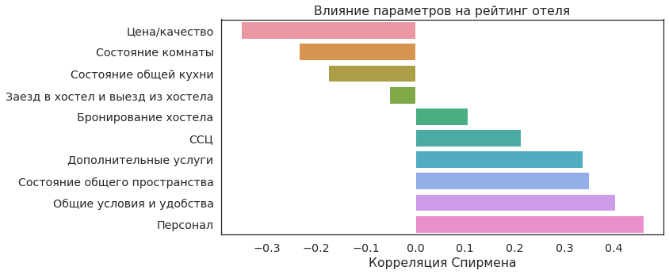

```python
plt.figure(figsize=(10, 5))
sns.barplot(y=correlations.index, x=correlations)
plt.title('Влияние параметров на рейтинг отеля')
plt.xlabel('Корреляция Спирмена');
```

Посмотрим, **как влияют признаки на обучение модели Random Forest**. Обучим 100 деревьев

```python
rf = RandomForestRegressor(n_estimators=100)
rf.fit(hostel.iloc[:, 1:-1], hostel.iloc[:, -1]);
```

Извлечем автоматически посчитаные важности признаков и отсортируем их по убыванию

```python
fi = pd.Series(
    rf.feature_importances_,
    index=hostel.iloc[:, 1:-1].columns
).sort_values(ascending=False)
```

Визуализируем

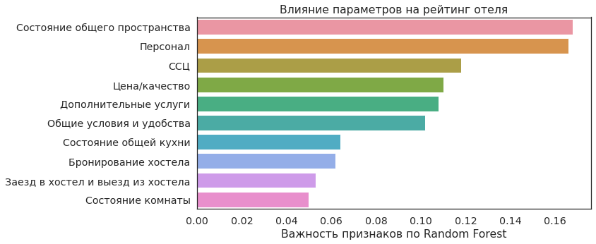

```python
plt.figure(figsize=(10, 5))
sns.barplot(y=fi.index, x=fi)
plt.title('Влияние параметров на рейтинг отеля')
plt.xlabel('Важность признаков по Random Forest');
```

[Еще пример на важность признаков](https://scikit-learn.org/stable/auto_examples/ensemble/plot_forest_importances_faces.html#sphx-glr-auto-examples-ensemble-plot-forest-importances-faces-py).

[Важность признаков в CatBoost](https://tech.yandex.com/catboost/doc/dg/concepts/fstr-docpage/).

### 1.3. Communities and Crime Data Set

Загрузим [данные](http://archive.ics.uci.edu/ml/datasets/Communities+and+Crime) на основе:

- переписи населения США 1990 года,
- данных правоохранительных органов из обследования US LEMAS 1990 года,
- данных о преступности от FBI UCR 1995 года.

Посмотрим на данные. В них есть некоторое количество пропусков, обозначенных в исходном файле символом `?`. В функции `read_csv` параметру `na_values` необходимо указать, как записаны пропуски в файле.

```python
df = pd.read_csv('./communities.data', header=None, na_values='?')
df.head(10)
```

|  | 0 | 1 | 2 | 3 | 4 | 5 | 6 | 7 | 8 | 9 | ... | 118 | 119 | 120 | 121 | 122 | 123 | 124 | 125 | 126 | 127 |
| --- | --- | --- | --- | --- | --- | --- | --- | --- | --- | --- | --- | --- | --- | --- | --- | --- | --- | --- | --- | --- | --- |
| 0 | 8 | NaN | NaN | Lakewoodcity | 1 | 0.19 | 0.33 | 0.02 | 0.90 | 0.12 | ... | 0.12 | 0.26 | 0.20 | 0.06 | 0.04 | 0.9 | 0.5 | 0.32 | 0.14 | 0.20 |
| 1 | 53 | NaN | NaN | Tukwilacity | 1 | 0.00 | 0.16 | 0.12 | 0.74 | 0.45 | ... | 0.02 | 0.12 | 0.45 | NaN | NaN | NaN | NaN | 0.00 | NaN | 0.67 |
| 2 | 24 | NaN | NaN | Aberdeentown | 1 | 0.00 | 0.42 | 0.49 | 0.56 | 0.17 | ... | 0.01 | 0.21 | 0.02 | NaN | NaN | NaN | NaN | 0.00 | NaN | 0.43 |
| 3 | 34 | 5.0 | 81440.0 | Willingborotownship | 1 | 0.04 | 0.77 | 1.00 | 0.08 | 0.12 | ... | 0.02 | 0.39 | 0.28 | NaN | NaN | NaN | NaN | 0.00 | NaN | 0.12 |
| 4 | 42 | 95.0 | 6096.0 | Bethlehemtownship | 1 | 0.01 | 0.55 | 0.02 | 0.95 | 0.09 | ... | 0.04 | 0.09 | 0.02 | NaN | NaN | NaN | NaN | 0.00 | NaN | 0.03 |
| 5 | 6 | NaN | NaN | SouthPasadenacity | 1 | 0.02 | 0.28 | 0.06 | 0.54 | 1.00 | ... | 0.01 | 0.58 | 0.10 | NaN | NaN | NaN | NaN | 0.00 | NaN | 0.14 |
| 6 | 44 | 7.0 | 41500.0 | Lincolntown | 1 | 0.01 | 0.39 | 0.00 | 0.98 | 0.06 | ... | 0.05 | 0.08 | 0.06 | NaN | NaN | NaN | NaN | 0.00 | NaN | 0.03 |
| 7 | 6 | NaN | NaN | Selmacity | 1 | 0.01 | 0.74 | 0.03 | 0.46 | 0.20 | ... | 0.01 | 0.33 | 0.00 | NaN | NaN | NaN | NaN | 0.00 | NaN | 0.55 |
| 8 | 21 | NaN | NaN | Hendersoncity | 1 | 0.03 | 0.34 | 0.20 | 0.84 | 0.02 | ... | 0.04 | 0.17 | 0.04 | NaN | NaN | NaN | NaN | 0.00 | NaN | 0.53 |
| 9 | 29 | NaN | NaN | Claytoncity | 1 | 0.01 | 0.40 | 0.06 | 0.87 | 0.30 | ... | 0.00 | 0.47 | 0.11 | NaN | NaN | NaN | NaN | 0.00 | NaN | 0.15 |

10 rows × 128 columns

```python
df.isna().mean()
```

```
0      0.000000
1      0.588766
2      0.590271
3      0.000000
4      0.000000
         ...
123    0.840020
124    0.840020
125    0.000000
126    0.840020
127    0.000000
Length: 128, dtype: float64
```

**Визуализируем матрицу корреляций Спирмена.**

У `pandas.DataFrame` есть встроенный метод, считающий попарные корреляции столбцов.

`pd.DataFrame.corr(method='pearson', min_periods=1)`

Считает попарные корреляции столбцов, игнорируя пропущенные значения, то есть только по парам, в которых оба значения присутствуют.

*Параметры:*

- `method` — один из трех `peason`, `kenall`, `spearman` или функция, принимающая два массива одной размерности и возвращающая вещественное число;
- `min_periods` — наименьшее количество пар, необходимых для корректного подсчета корреляции.

*Возвращает:*

- таблица попарных корреляций в виде `pandas.DataFrame`.

Визуально кажется, что имеются кластеры признаков, то есть группы признаков, внутри которых признаки сильно коррелирую друг с другом.

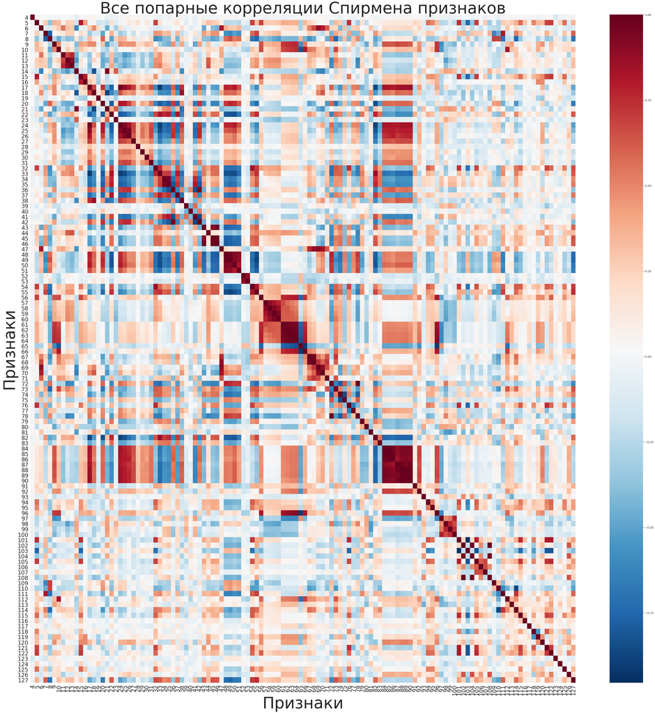

```python
correlation_matrix = df.iloc[:, 4:].corr(method='spearman')

plt.figure(figsize=(50, 50))
sns.heatmap(correlation_matrix, cmap='RdBu_r')
plt.xlabel('Признаки', fontsize=80)
plt.ylabel('Признаки', fontsize=80)
plt.title('Все попарные корреляции Спирмена признаков', fontsize=80)
plt.xticks(fontsize=28), plt.yticks(fontsize=28)
plt.tight_layout()
```

Для **кластеризации признаков** воспользуемся методом иерархической кластеризации.

- Сначала на основе корреляций *определим матрицу расстояний между признаками* по правилу $$dist(i, j) = 1 - \left| \widehat{corr}(X_i, X_j) \right|.$$
- На основе этих расстояний *построим дендрограмму*, которая по определенным расстояниям выделит кластеры параметров и упорядочит признаки в соответствии с этими кластерами.
- В этом порядке отобразим корреляционную матрицу.

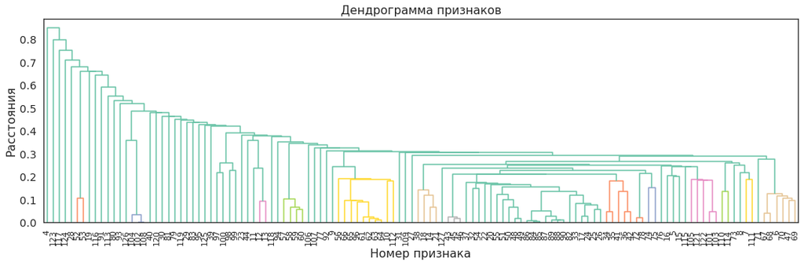

[output not shown]

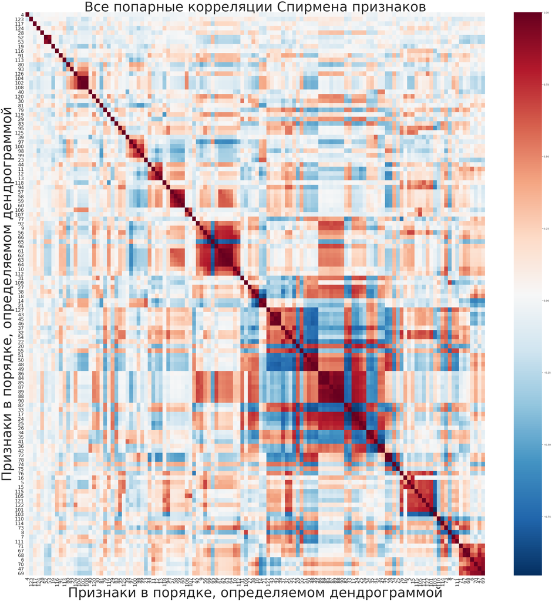

```python
# матрица расстояний
dist_matrix = np.array(1 - correlation_matrix.abs())
# если какие-то корреляции не определены, заменим расстояния на 1
# вне диагонали, и 0 на диагонале
dist_matrix[np.isnan(dist_matrix)] = \
    (1 - np.eye(len(dist_matrix)))[np.isnan(dist_matrix)]

# Определение вспомогательных объектов для кластеризации
dists = squareform(dist_matrix)
linkage_matrix = linkage(dists, "single")

# Отрисовка дентрограммы
plt.figure(figsize=(18, 5))
dendrogram_result = dendrogram(
    linkage_matrix,
    orientation='top',
    labels=correlation_matrix.columns,
    color_threshold=0.2,
    distance_sort='descending',
    show_leaf_counts=True
)
plt.xticks(fontsize=11)
plt.xlabel('Номер признака')
plt.ylabel('Расстояния')
plt.title('Дендрограмма признаков')
plt.show()

# создаем корреляционную матрицу с параметрами в нужном порядке
correlation_matrix = df[dendrogram_result['ivl']].corr(method='spearman')

plt.figure(figsize=(50, 50))
sns.heatmap(correlation_matrix, cmap='RdBu_r')
plt.xticks(fontsize=28), plt.yticks(fontsize=28)
plt.xlabel('Признаки в порядке, определяемом дендрограммой', fontsize=80)
plt.ylabel('Признаки в порядке, определяемом дендрограммой', fontsize=80)
plt.title('Все попарные корреляции Спирмена признаков', fontsize=80)
plt.tight_layout();

# Печать самих кластеров
clusters = fcluster(linkage_matrix, 0.2, criterion='distance')
elements, repeats = np.unique(clusters, return_counts=True)
for cl in elements[repeats > 1]:
    print(
        'Кластер из {} признаков {}'.format(
            (clusters == cl).sum(),
            list(df.iloc[:, 4:].columns[clusters == cl])
        )
    )
```

## 2. Категориальные признаки.

Коэффициенты корреляции не применимы к категориальным признакам, к ним применяют методы, основанные на таблицах сопряженности. Мы будем использовать **критерий хи-квадрат, основанный на таблице сопряженности**.

Пусть даны выборки $X = (X_1, \dots, X_n)$ и $Y = (Y_1, \dots, Y_n)$ категориальных значений. Пусть, для определенности, $X_i \in \{1, \dots, k_1\}$, а $Y_j \in \{1, \dots, k_2\}$. Обозначим

- $n_{ij} = \#\{s\:|\:X_s = i\ и\ Y_s = j\}$,
- $n_{\bullet j} = \#\{s\:|\:Y_s = j\}$,
- $n_{i \bullet} = \#\{s\:|\:X_s = i\}$.

Статистикой критерия хи-квадрат является $${\Large \chi^2(X, Y) = \sum_{i=1}^{k_1}\sum_{j=1}^{k_2} \frac{\left( n_{ij} - \frac{n_{i \bullet} n_{\bullet j}}{n} \right)^2}{\frac{n_{i \bullet} n_{\bullet j}}{n}}},$$ которая при независимости выборок сходится по распределению к $\chi^2_{(k_1 - 1)(k_2 - 1)}$.

**Реализация.**

#### `scipy.stats.chi2_contingency(observed, correction=True, lambda_=None)`

*Параметры*:

- `observed` — таблица сопряженности;
- `correction` — нужно ли применять в случае одной степени свободы [поправку Йейтcа](https://en.wikipedia.org/wiki/Yates%27s_correction_for_continuity), точнее вычисляющую статистику критерия при маленьких размерах выборки.

*Возвращаемые значения*:

- `chi2` — статистика критерия;
- `p` — p-value критерия;
- `dof` — количество степеней свободы распределения хи-квадрат, то есть $(k_1 - 1)(k_2 - 1)$ в обозначениях выше;
- `expected` — таблица ожидаемых значений при условии независимости выборок, то есть состоит из элементов $\frac{n_{i \bullet} n_{\bullet j}}{n}$.

Одно из условий применимости критерия состоит в том, что не более, чем для 20% пар $(i, j)$ выполнено, что $\frac{n_{i \bullet} n_{\bullet j}}{n} < 5$. Таким образом, последнее возвращаемое значение можно использовать для определения применимости критерия. В случае же его неприменимости можно объединять значения категориальных переменных, подобно классическому критерию хи-квадрат.

```python
def cramer(chi2, n, k1, k2):
    """
    Коэффициент Крамера, считающийся по статистике критерия хи-квадрат

    :param chi2: Статистика критерия хи-квадрат
    :param n: Размер выборки
    :param k1: Количество различных значений первой выборки
    :param k2: Количество различных значений второй выборки

    :returns: Коэффициент корреляции Крамера
    """

    return np.sqrt(chi2 / (n * min(k1, k2) - 1))


def matthews(table2x2):
    """
    Коэффициент контингенции таблицы 2х2
    """

    table2x2 = np.array(table2x2)
    a, b = table2x2[0]
    c, d = table2x2[1]
    return (a*d - b*c) / np.sqrt((a+b) * (a+c) * (b+d) * (c+d))
```

### 2.1. Отток клиентов

Загрузим **[данные](https://github.com/Yorko/mlcourse_open/blob/master/data/telecom_churn.csv) о клиентах оператора связи**, которые содержат некоторую информацию тарифном плане клиента, статистику его использования услуг связи, а также его **текущий статус `Churn` — ушел или нет**.

```python
telecom = pd.read_csv('./telecom_churn.csv')
telecom.head()
```

|  | State | Account length | Area code | International plan | Voice mail plan | Number vmail messages | Total day minutes | Total day calls | Total day charge | Total eve minutes | Total eve calls | Total eve charge | Total night minutes | Total night calls | Total night charge | Total intl minutes | Total intl calls | Total intl charge | Customer service calls | Churn |
| --- | --- | --- | --- | --- | --- | --- | --- | --- | --- | --- | --- | --- | --- | --- | --- | --- | --- | --- | --- | --- |
| 0 | KS | 128 | 415 | No | Yes | 25 | 265.1 | 110 | 45.07 | 197.4 | 99 | 16.78 | 244.7 | 91 | 11.01 | 10.0 | 3 | 2.70 | 1 | False |
| 1 | OH | 107 | 415 | No | Yes | 26 | 161.6 | 123 | 27.47 | 195.5 | 103 | 16.62 | 254.4 | 103 | 11.45 | 13.7 | 3 | 3.70 | 1 | False |
| 2 | NJ | 137 | 415 | No | No | 0 | 243.4 | 114 | 41.38 | 121.2 | 110 | 10.30 | 162.6 | 104 | 7.32 | 12.2 | 5 | 3.29 | 0 | False |
| 3 | OH | 84 | 408 | Yes | No | 0 | 299.4 | 71 | 50.90 | 61.9 | 88 | 5.26 | 196.9 | 89 | 8.86 | 6.6 | 7 | 1.78 | 2 | False |
| 4 | OK | 75 | 415 | Yes | No | 0 | 166.7 | 113 | 28.34 | 148.3 | 122 | 12.61 | 186.9 | 121 | 8.41 | 10.1 | 3 | 2.73 | 3 | False |

Количество клиентов в данных

```python
n = len(telecom)
n
```

```
3333
```

#### A. Зависимость оттока от количества звонков в службу поддержки

Гистограмма количества звонков в службу поддержки для клиентов в оттоке и не в оттоке. Как видим, клиенты из оттока в среднем чаще совершают звонки в службу поддержки.

```python
d1, x1 = np.histogram(
    telecom[telecom['Churn']]['Customer service calls'],
    range=(0, 10), bins=10, density=True
)
d2, x2 = np.histogram(
    telecom[~telecom['Churn']]['Customer service calls'],
    range=(0, 10), bins=10, density=True
)
dens = pd.DataFrame(
    np.array([
        np.append(d1, d2),
        np.append(x1[:-1], x2[:-1]),
        [1]*10 + [0]*10]
    ).T,
    columns=['density', 'Customer service calls', 'Churn']
)
```

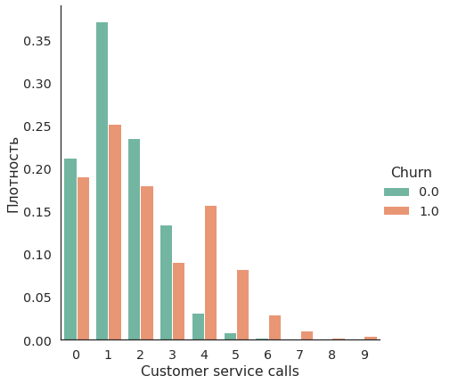

```python
sns.set(style='white', font_scale=1.3, palette='Set2')

sns.catplot(
    data=dens,
    x='Customer service calls',
    y='density',
    hue='Churn',
    kind='bar',
    height=6
)
plt.xticks(np.arange(10), np.arange(10).astype(str))
plt.ylabel('Плотность');
```

Будем применять критерий хи-квадрат. Подадим таблицу как есть, и проверим применимость. Доля клеток, в которых ожидаемое количество меньше 5 получилась больше 20%, поэтому надо делать объединения клеток.

```python
obs = pd.crosstab(
    telecom['Churn'], telecom['Customer service calls']
)

obs
```

| Customer service calls Churn | 0 | 1 | 2 | 3 | 4 | 5 | 6 | 7 | 8 | 9 |
| --- | --- | --- | --- | --- | --- | --- | --- | --- | --- | --- |
| False | 605 | 1059 | 672 | 385 | 90 | 26 | 8 | 4 | 1 | 0 |
| True | 92 | 122 | 87 | 44 | 76 | 40 | 14 | 5 | 1 | 2 |

```python
chi2, p, dof, expected = sps.chi2_contingency(obs)
(expected < 5).mean()
```

```
0.3
```

Объединяем два последних столбца.

```python
obs['>7'] = obs[8] + obs[9]
del obs[8], obs[9]

obs
```

| Customer service calls Churn | 0 | 1 | 2 | 3 | 4 | 5 | 6 | 7 | >7 |
| --- | --- | --- | --- | --- | --- | --- | --- | --- | --- |
| False | 605 | 1059 | 672 | 385 | 90 | 26 | 8 | 4 | 1 |
| True | 92 | 122 | 87 | 44 | 76 | 40 | 14 | 5 | 3 |

Опять не получилось...

```python
chi2, p, dof, expected = sps.chi2_contingency(obs)
(expected < 5).mean()
```

```
0.2222222222222222
```

Еще раз объединяем последние столбцы.

```python
obs['>6'] = obs[7] + obs['>7']
del obs[7], obs['>7']

obs
```

| Customer service calls Churn | 0 | 1 | 2 | 3 | 4 | 5 | 6 | >6 |
| --- | --- | --- | --- | --- | --- | --- | --- | --- |
| False | 605 | 1059 | 672 | 385 | 90 | 26 | 8 | 5 |
| True | 92 | 122 | 87 | 44 | 76 | 40 | 14 | 8 |

На этот раз все нормально.

```python
chi2, p, dof, expected = sps.chi2_contingency(obs)
(expected < 5).mean()
```

```
0.125
```

Получаемое число степеней свободы равно $(8 - 1) \cdot (2 - 1) = 7$, все правильно

```python
dof
```

```
7
```

Значение статистики и pvalue, **наблюдается статистически значимая зависимость**

```python
chi2, p
```

```
(339.8121374370096, 1.8667121238838202e-69)
```

Коэффициент Крамера

```python
cramer(chi2, n, 8, 2)
```

```
0.22579762345348267
```

#### B. Зависимость оттока от тарифного плана

```python
np.unique(telecom['International plan'])
```

```
array(['No', 'Yes'], dtype=object)
```

В этом случае получаем таблицу 2 на 2

```python
obs = pd.crosstab(telecom['Churn'], telecom['International plan'])
obs
```

| International plan Churn | No | Yes |
| --- | --- | --- |
| False | 2664 | 186 |
| True | 346 | 137 |

Результат применения критерия хи-квадрат **статистически значим**

```python
chi2, p, dof, expected = sps.chi2_contingency(obs)
chi2, p, dof
```

```
(222.5657566499376, 2.4931077033159556e-50, 1)
```

Коэффициенты Крамера и Мэтьюса

```python
cramer(chi2, n, 2, 2), matthews(obs)
```

```
(0.1827380961935435, 0.25985184734548217)
```

#### C. Зависимость оттока от тарифного плана голосовой почты

Все аналогично.

```python
np.unique(telecom['Voice mail plan'])
```

```
array(['No', 'Yes'], dtype=object)
```

```python
obs = pd.crosstab(telecom['Churn'], telecom['Voice mail plan'])
obs
```

| Voice mail plan Churn | No | Yes |
| --- | --- | --- |
| False | 2008 | 842 |
| True | 403 | 80 |

```python
chi2, p, dof, expected = sps.chi2_contingency(obs)
chi2, p, dof
```

```
(34.13166001075673, 5.15063965903898e-09, 1)
```

Статистическая значимость имеется, в то время как практическая значимость может быть поставлена под сомнение

```python
cramer(chi2, n, 2, 2), matthews(obs)
```

```
(0.07156136708398074, -0.10214814067014692)
```

#### D. Зависимость оттока от количества минут днем

В данном случае нужно исследовать зависимость двух переменных, из которых одна вещественная, а другая -- бинарная. Для начала можно построить две KDE, по которым уже видна зависимость.

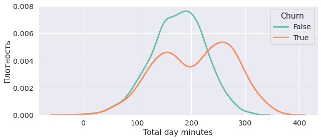

```python
sns.set(font_scale=1.3, palette='Set2')

plt.figure(figsize=(10, 4))
sns.kdeplot(
    telecom[telecom['Churn'] == False]['Total day minutes'],
    label='False', lw=3
)
sns.kdeplot(
    telecom[telecom['Churn'] == True]['Total day minutes'],
    label='True', lw=3
)
plt.legend(title='Churn')

plt.ylabel('Плотность')
plt.xlabel('Total day minutes')
plt.show()
```

Чтобы исследовать статистическую зависимость, разобьем вещественную переменную на несколько интервалов, тем самым сведя ее к категориальной. После этого можно построить таблицу сопряженности.

```python
obs = np.histogram2d(
    telecom['Churn'],
    telecom['Total day minutes'],
    bins=(2, 5)
)[0]

obs
```

```
array([[  71.,  592., 1478.,  674.,   35.],
       [  10.,   88.,  132.,  184.,   69.]])
```

Применяем критерий хи-квадрат. **Статистическая значимость имеется.**

```python
sps.chi2_contingency(obs)
```

```
(312.22807558569394,
 2.4931581541229795e-66,
 4,
 array([[  69.26192619,  581.45814581, 1376.68766877,  733.66336634,
           88.92889289],
        [  11.73807381,   98.54185419,  233.31233123,  124.33663366,
           15.07110711]]))
```

#### E. Зависимость оттока от количества минут ночью

Все аналогично

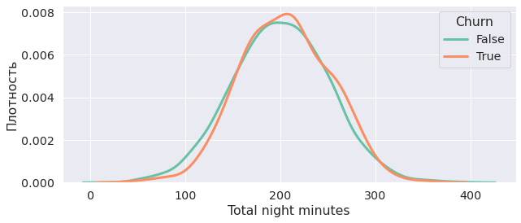

```python
plt.figure(figsize=(10, 4))
sns.kdeplot(
    telecom[telecom['Churn'] == False]['Total night minutes'],
    label='False', lw=3
)
sns.kdeplot(
    telecom[telecom['Churn'] == True]['Total night minutes'],
    label='True', lw=3
)
plt.legend(title='Churn')
plt.ylabel('Плотность')
plt.xlabel('Total night minutes')

plt.show()
```

```python
obs = np.histogram2d(
    telecom['Churn'],
    telecom['Total night minutes'],
    bins=(2, 5)
)[0]

obs
```

```
array([[  62.,  772., 1499.,  488.,   29.],
       [   5.,  120.,  259.,   96.,    3.]])
```

```python
sps.chi2_contingency(obs)
```

```
(5.992610695316391,
 0.19970079123233955,
 4,
 array([[  57.29072907,  762.73627363, 1503.24032403,  499.36993699,
           27.36273627],
        [   9.70927093,  129.26372637,  254.75967597,   84.63006301,
            4.63726373]]))
```

Интересно, что в этом случае **результат статистически незначим**. Т.е. получаем, что отток зависит от дневных минут и не зависит от ночных.

#### Итог:

- Зависимость оттока от количества звонков в службу поддержки — **да, статистически значимо**;
- Зависимость оттока от тарифного плана — **да, статистически значимо**;
- Зависимость оттока от тарифного плана голосовой почты — **сомнительно**;
- Зависимость оттока от количества минут днем — **да, статистически значимо**;
- Зависимость оттока от количества минут ночью — **нет статистической значимости**.

Источники данных: 1, [2](https://github.com/datasets/openml-datasets/blob/master/data/kr-vs-kp/kr-vs-kp.csv).

Данные состоят некоторого количества бинарных переменных, которые задают комбинацию в игре, а так же результата игры с такой позицией.

```python
kr_vs_kp = pd.read_csv('kr-vs-kp.csv')
kr_vs_kp.head()
```

|  | bkblk | bknwy | bkon8 | bkona | bkspr | bkxbq | bkxcr | bkxwp | blxwp | bxqsq | ... | spcop | stlmt | thrsk | wkcti | wkna8 | wknck | wkovl | wkpos | wtoeg | class |
| --- | --- | --- | --- | --- | --- | --- | --- | --- | --- | --- | --- | --- | --- | --- | --- | --- | --- | --- | --- | --- | --- |
| 0 | 'f' | 'f' | 'f' | 'f' | 'f' | 'f' | 'f' | 'f' | 'f' | 'f' | ... | 'f' | 'f' | 'f' | 'f' | 'f' | 'f' | 't' | 't' | 'n' | 'won' |
| 1 | 'f' | 'f' | 'f' | 'f' | 't' | 'f' | 'f' | 'f' | 'f' | 'f' | ... | 'f' | 'f' | 'f' | 'f' | 'f' | 'f' | 't' | 't' | 'n' | 'won' |
| 2 | 'f' | 'f' | 'f' | 'f' | 't' | 'f' | 't' | 'f' | 'f' | 'f' | ... | 'f' | 'f' | 'f' | 'f' | 'f' | 'f' | 't' | 't' | 'n' | 'won' |
| 3 | 'f' | 'f' | 'f' | 'f' | 'f' | 'f' | 'f' | 'f' | 't' | 'f' | ... | 'f' | 'f' | 'f' | 'f' | 'f' | 'f' | 't' | 't' | 'n' | 'won' |
| 4 | 'f' | 'f' | 'f' | 'f' | 'f' | 'f' | 'f' | 'f' | 'f' | 'f' | ... | 'f' | 'f' | 'f' | 'f' | 'f' | 'f' | 't' | 't' | 'n' | 'won' |

5 rows × 37 columns

**Проведем анализ влияния параметров позиции на итог игры.** Для этого для каждого параметра применим критерий хи-квадрат, посчитаем коэффициенты Крамера и Мэтьюса. К результатам применения критерия хи-квадрат применим так же МПГ по методу Холма. Столбец `value` соответствует "положительному" значению в терминах коэффициентов Крамера и Мэтьюса.

```python
influence = pd.DataFrame(columns=[
    'value', 'chi2', 'pvalue', 'reject', 'cramer', 'matthews'
])

features = kr_vs_kp.columns[:-1]
n = len(kr_vs_kp)

for f in features:
    # Для каждого признака применяем критерий хи-квадрат
    obs = pd.crosstab(kr_vs_kp[f], kr_vs_kp['class'])
    chi2, p, _, _ = sps.chi2_contingency(obs)

    # Записываем статистику критерия, p-value, коэффициенты Крамера и Мэтьюса.
    series = pd.Series({
        'value': obs.index[0],
        'chi2': chi2,
        'pvalue': p,
        'reject': p < 0.05,
        'cramer': cramer(chi2, n, 2, 2),
        'matthews': matthews(obs)
    })
    series.name = f
    influence = influence.append(series)

# Применяем МПГ
reject_corrected, pvalues_corrected, _, _ = multipletests(
    influence['pvalue'],
    method='holm',
)

influence['corrected_pvalue'] = pvalues_corrected
influence['reject_holm'] = reject_corrected
```

Посмотрим на результаты

```python
influence['matthews_abs'] = np.abs(influence['matthews'])
influence.sort_values(by='matthews_abs', ascending=False).iloc[:, :-1]
```

|  | value | chi2 | pvalue | reject | cramer | matthews | corrected_pvalue | reject_holm |
| --- | --- | --- | --- | --- | --- | --- | --- | --- |
| rimmx | 'f' | 651.435295 | 1.088838e-143 | True | 0.319265 | 0.452284 | 3.919818e-142 | True |
| bxqsq | 'f' | 460.095072 | 4.583551e-102 | True | 0.268312 | -0.380101 | 1.604243e-100 | True |
| wknck | 'f' | 424.899908 | 2.093813e-94 | True | 0.257845 | -0.365265 | 7.118965e-93 | True |
| bkxwp | 'f' | 172.243093 | 2.394809e-39 | True | 0.164167 | -0.232908 | 7.902870e-38 | True |
| wkna8 | 'f' | 121.752418 | 2.615189e-28 | True | 0.138024 | -0.196557 | 8.107087e-27 | True |
| r2ar8 | 'f' | 85.803472 | 1.987369e-20 | True | 0.115869 | -0.164526 | 5.962108e-19 | True |
| bkxcr | 'f' | 85.100239 | 2.836162e-20 | True | 0.115393 | -0.163828 | 8.224870e-19 | True |
| mulch | 'f' | 78.661185 | 7.373009e-19 | True | 0.110942 | -0.158337 | 2.064442e-17 | True |
| wkpos | 'f' | 67.971542 | 1.658723e-16 | True | 0.103129 | 0.146543 | 4.478552e-15 | True |
| bkxbq | 'f' | 61.903982 | 3.606196e-15 | True | 0.098418 | 0.139802 | 9.376109e-14 | True |
| skrxp | 'f' | 53.266420 | 2.912429e-13 | True | 0.091294 | -0.130476 | 7.281071e-12 | True |
| stlmt | 'f' | 50.034793 | 1.510438e-12 | True | 0.088481 | -0.127724 | 3.474008e-11 | True |
| wkcti | 'f' | 50.360744 | 1.279278e-12 | True | 0.088769 | 0.126350 | 3.070267e-11 | True |
| rkxwp | 'f' | 32.356829 | 1.283055e-08 | True | 0.071154 | 0.101402 | 2.822721e-07 | True |
| dwipd | 'g' | 31.251496 | 2.266727e-08 | True | 0.069928 | 0.099563 | 4.760127e-07 | True |
| bkon8 | 'f' | 25.609635 | 4.179472e-07 | True | 0.063302 | -0.091163 | 8.358945e-06 | True |
| rxmsq | 'f' | 23.886245 | 1.021994e-06 | True | 0.061135 | -0.087799 | 1.941788e-05 | True |
| blxwp | 'f' | 22.834490 | 1.765684e-06 | True | 0.059774 | -0.085171 | 3.178232e-05 | True |
| katri | 'b' | 154.274708 | 3.159896e-34 | True | 0.155368 | 0.076105 | 1.011167e-32 | True |
| hdchk | 'f' | 14.436453 | 1.449688e-04 | True | 0.047528 | -0.071791 | 2.319501e-03 | True |
| cntxt | 'f' | 14.558650 | 1.358635e-04 | True | 0.047728 | 0.068125 | 2.309679e-03 | True |
| simpl | 'f' | 6.460625 | 1.102909e-02 | True | 0.031795 | 0.045605 | 1.654363e-01 | False |
| wkovl | 'f' | 5.021603 | 2.503299e-02 | True | 0.028031 | -0.040287 | 3.504618e-01 | False |
| thrsk | 'f' | 4.792972 | 2.857607e-02 | True | 0.027385 | 0.040277 | 3.714890e-01 | False |
| skach | 'f' | 3.848425 | 4.979273e-02 | True | 0.024539 | -0.040049 | 4.979273e-01 | False |
| bkspr | 'f' | 4.645799 | 3.112965e-02 | True | 0.026962 | -0.038791 | 3.735558e-01 | False |
| skewr | 'f' | 4.214011 | 4.009142e-02 | True | 0.025678 | -0.036991 | 4.410056e-01 | False |
| reskd | 'f' | 2.391095 | 1.220282e-01 | False | 0.019343 | 0.030839 | 1.000000e+00 | False |
| spcop | 'f' | 0.001979 | 9.645207e-01 | False | 0.000556 | -0.018496 | 1.000000e+00 | False |
| dsopp | 'f' | 0.659828 | 4.166208e-01 | False | 0.010161 | 0.015390 | 1.000000e+00 | False |
| bkona | 'f' | 0.442373 | 5.059792e-01 | False | 0.008320 | -0.012806 | 1.000000e+00 | False |
| qxmsq | 'f' | 0.344931 | 5.569966e-01 | False | 0.007347 | 0.012214 | 1.000000e+00 | False |
| reskr | 'f' | 0.140819 | 7.074687e-01 | False | 0.004694 | 0.007513 | 1.000000e+00 | False |
| bknwy | 'f' | 0.019222 | 8.897321e-01 | False | 0.001734 | 0.003677 | 1.000000e+00 | False |
| bkblk | 'f' | 0.000060 | 9.937975e-01 | False | 0.000097 | 0.001132 | 1.000000e+00 | False |
| wtoeg | 'n' | 0.001504 | 9.690686e-01 | False | 0.000485 | -0.000040 | 1.000000e+00 | False |

Как видим, после применения МПГ мы не нашли влияния некоторых признаков на исход игры. Поэтому можно предположить, что они являются менее важными в смысле влияния на результат.